# Lab2

Author

Jane He and Monica Orme

Published

January 26, 2024

# Goals for Today

- Clarifying Questions from Lab 1
- How to Set up Working Directory?
- How to Import and Access Datasets?
- How to Create and Save Graphs?
- How to Compile a report in R?
- Practice with Lab Activity

# Setting up Directory

It is important that **both you and R** are on the same page of where to find files.

## What is a directory?

- You can think it as a folder on computer
- We can use directories to move and organize different files on computer
  - For example, I have a folder named “PSC103A” that solely store all the materials related to the course
- Directories can be nested within one another to further group related files
  - For example, I have sub-folders (“Lab1”, “Lab2”, etc.) within the “PSC103A” folder to sort materials for each lab

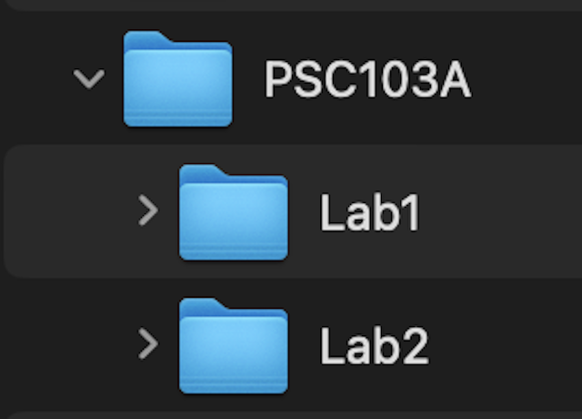

## What is a path?

- You can think it as the address to your folders on computer
- A path gives the location of a directory
- Paths usually appear in the address bar of your file explorer
  - For example, on a Mac:
    - Visually, it look like this:

[figure not shown]

    - In the language of that a computer can understand, it looks like:

      `/Users/jane/Documents/GitHub/PSC103A/Lab2`

## What is a working directory?

- It is the default folder that R is currently in
- It is where R will find, read, and write files by default
- You have only one working directory at a time
- We can tell R where is its “office” on your computer that you want it to work in by specifying a path to a directory
  - For example, I want to work in my folder for PSC103A Lab2:
    - To set a working directory

      ```r
      # Example for a Mac
      setwd(dir = "/Users/jane/Documents/GitHub/PSC103A/Lab2")
      # Example for a PC
      setwd(dir = "C:\\Users\\Monica\\Documents\\GitHub\\PSC103A\\Lab2")
      ```

      - Note for PC: Using double slashes (\\ or //) instead of single slashes (\) may be needed when specifying the path. Otherwise, the path may not be read into R correctly.
    - To verify the working directory

      ```r
      # Same command on Mac and PC
      getwd()
      ```

      ```
      [1] "C:/Users/Monica/OneDrive/st - PSC 103A/Discussions-Labs/Lab Slides-Code"
      ```

## Bonus Tip: Absolute vs. Relative Path

- A path can be absolute or relative
  - **Absolute** path is the **full** path from the very first **root directory**
    - When we want to access files stored **outside** of our working directory, R needs the full path to the file(s). For examples:
      - On a Mac, a full path to my directory for PSC103A Lab 2 materials is: `/Users/jane/Documents/GitHub/PSC103A/Lab2/Lab2.qmd`
      - On a PC, a full path to my directory for PSC103A Lab 2 materials is: `C:\\Users\\Monica\\Documents\\GitHub\\PSC103A\\Lab2\\Lab2.qmd`
  - **Relative** path is the path **relative** to the **working directory**
    - When we have the file(s) stored **inside** our working directory, R only needs the relative path in order to access. For examples:
      - On a Mac, a relative path to my directory for PSC103A Lab 2 materials is: `Lab2/Lab2.qmd`
      - On a PC, a relative path to my directory for PSC103A Lab 2 materials is: `Lab2\\Lab2.qmd`

# Importing Data Files

R supports many data file formats; some common formats including .csv, .xlsx, .txt and more.

For this course, we will focus on .txt and .csv formats.

## .txt vs. .csv

- .txt (Text): plain text file, contains human-readable text.
  - Used for general-purpose storage of text data
- .csv (Comma-Separated Values): specific type of text file where data is separated by commas
  - Common choice for data exchange as it is suitable for representing tables of data
  - If you expect the need to switch between any spreadsheets or databases, this is the better option to go with

## How to Import?

There are many R functions can be used to import data files, some are more flexible for certain format than the others.

- Recall that a R object can be anything
  - We always should store our imported dataset as R object in R environment
- With .txt file, we can use `read.table()` to read in the dataset:

  ```r
  # create an object with self-explanatory name to store the dataset
  lab2_data_txt <- read.table(
                      file = "LearningModule2/lab2data.txt",
                          # specify the directory of the file
                          ## I am in my working directory, so the relative path works
                      header = TRUE,
                          # tell R to recognize the first row as variable names
                      stringsAsFactors = TRUE)
                          # tell R to convert character values into factors
  ```

- With .csv file, we can use `read.csv()` to read in the dataset:

  ```r
  #A02

  # create an object with self-explanatory name to store the dataset
  lab2_data_csv <- read.csv(
                      file = "C:\\Users\\Monica\\OneDrive\\st - PSC 103A\\Discussions-Labs\\Data\\lab2data.csv",
                          # specify the directory of the file
                          ## a full path will always work, but especially when you don't set up working directory
                      header = TRUE)
                          # tell R to recognize the first row as variable names
  ```

## After Importing

Once we imported the dataset and stored it as an object, let’s check if we have done everything correctly.

- Let’s take a quick look at the R Environment.

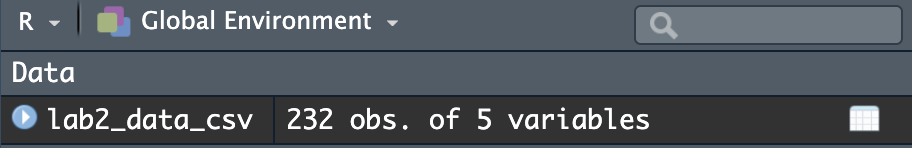

  - This can tell us that this dataset consists of 5 variables and has a total of 232 data records
- We can check the behavior of our dataset by using `head()` to print out the fews rows of the dataset. Because we are only doing a quick check, we don’t have to store it as an object.

  ```r
  # I am going with the .csv file for personal preference
  head(lab2_data_csv, # specify the object we want to check
       n = 6) # specify how many rows we want to print out
  ```

  |  | biosex | height_in | weight_lbs | age_yr | ed_cmplt |
  | --- | --- | --- | --- | --- | --- |
  | 1 | MALE | 72.2 | 146.4 | 20.0 | College2YR |
  | 2 | FEMALE | 61.5 | 103.8 | 22.7 | College4YR |
  | 3 | MALE | 68.4 | 162.7 | 25.7 | MA |
  | 4 | MALE | 69.6 | 151.8 | 22.9 | College4YR |
  | 5 | FEMALE | 62.3 | 117.7 | 23.4 | College4YR |
  | 6 | MALE | 67.5 | 132.1 | 20.2 | College2YR |

- Note: by default, R displays 6 rows if you omit the “n” argument. You can check by using either `?head()` or `help(head)`.

## After Importing

Let’s also check the data types of the variables in our dataset to make sure they align with our expectations.

- We can check all the variables entirely by using `str()`:

  ```r
  str(lab2_data_csv) # specify the object we want to check
  ```

  ```
  'data.frame':   232 obs. of  5 variables:
   $ biosex    : chr  "MALE" "FEMALE" "MALE" "MALE" ...
   $ height_in : num  72.2 61.5 68.4 69.6 62.3 67.5 69.9 58.9 57.9 NA ...
   $ weight_lbs: num  146 104 163 152 118 ...
   $ age_yr    : num  20 22.7 25.7 22.9 23.4 20.2 20.1 23.1 30.6 28.2 ...
   $ ed_cmplt  : chr  "College2YR" "College4YR" "MA" "College4YR" ...
  ```

  - Note here that we are seeing a new data type:
    - This object, `lab2_data_csv` , is a **data frame** which represents a table of data
  - We would also expect that variables `biosex` and `ed_cmplt` to be categorical as it has two or more levels. But they are not here. This is because, in the `read.csv()` function, I didn’t set the `stringsAsFactors` argument to `True` when importing.

## After Importing

Let’s convert variables `biosex` and `ed_cmplt` into their correct data type.

- We can convert them into a data type called **factor**, which represents categorical variables, by using `as.factor()` in combination with the “$” sign to specify the desired variables:
  - The “$” sign allows us to extract content from a single object. In this case, we are asking R to select a column of data by specifying the variable name of the column.

    ```r
    # overwrite previous values by reassigning
    lab2_data_csv$biosex <- as.factor(lab2_data_csv$biosex) # specify the object and variable wanted to convert
    lab2_data_csv$ed_cmplt <- as.factor(lab2_data_csv$ed_cmplt) # specify the object and variable wanted to convert
    ```

- To only check specific variables, we can use `class()` with “$” sign:

  ```r
  class(lab2_data_csv$biosex) # specify the object and variable wanted to check
  ```

  ```
  [1] "factor"
  ```

  ```r
  class(lab2_data_csv$ed_cmplt) # specify the object and variable wanted to check
  ```

  ```
  [1] "factor"
  ```

  - Now we see factor as the data type for variables `biosex` and `ed_cmplt` 🎉

# Creating Data Visualizations

Data visualizations (or graphical displays) are an important step in summarizing data and gaining a better understanding of it. There are various ways to visualize categorical and numerical data.

## Review: Types of Data

### Categorical Data

- Categorical data refer to variables with response options that are categories.
  - These do not have numeric properties (e.g. gender, graduation status).
- A **bar chart** is a common graph to visually display categorical data.
- Types of Bar Charts
  - Bar Chart: compare the categories of 1 group
  - Comparative Bar Chart: compare the categories among 2+ groups
  - Segmented (or Stacked) Bar Charts: display the relative frequencies across groups

### Numeric Data

- Numeric data are measured in some numerical unit. There are 2 types of numeric data:
  - Discrete (counts)
    - Examples: number of pets in a household, number of students in a course
  - Continuous (measurements)
    - Examples: weights of pets, age
- Some common ways to visualize numeric data include:
  - Histograms
  - Dot Plots
  - Stem-Leaf Plots

## Graphical Displays: Bar Charts

- Bart charts are used to compare the categories of **1 nominal variable**.
- Displayed as graphs of a frequency distribution for a categorical data set.
- Each category is represented by a bar, and the area of the bar is proportional to the corresponding **frequency** or **relative frequency**.
  - Refresh**:** A **relative frequency** is the **proportion of observations in a category**. It can range between 0 and 1.
  - **Relative Frequency =** (frequency)/(# of observations in the dataset)
- The bars within the chart **must not touch**.

## Graphical Displays: Bar Charts

A bar chart requires the frequencies or relative frequencies for each category, so we need to **create a new object** that includes the frequencies/relative frequencies of each category.  
Steps to plot in R:

1. Use the `table()` function to produce the frequencies
2. (If creating relative frequencies) Divide the frequencies by the total number of observations
3. Plot the frequencies/relative of the categories using the `barplot()` function. Format for plotting:

   ```r
   barplot(data_freq, # frequncies or relative frequencies
           main = "Variable Name",
           # 'main' title for the graph
           ylab = "Frequency/Relative Frequency",
           # 'ylab' label the y-axis
           names.arg = c("Category 1", "Category 2"),
           # 'names.arg' label the categories
           col = c(2,4))
           # 'col' change the bar colors
   ```

In learning module 2, we produced a bar chart to visualize the relative frequencies of the education levels.

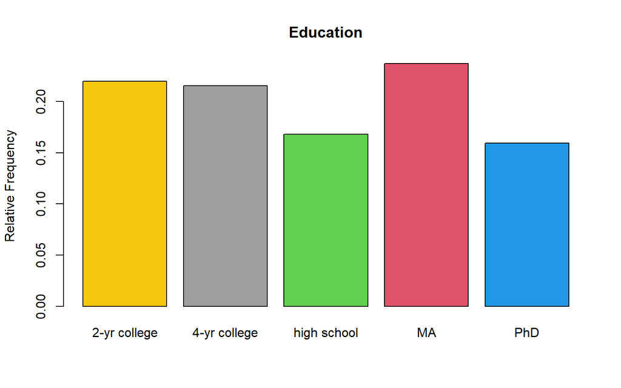

```r
educ_freq = table(lab2_data_csv$ed_cmplt) # produce frequencies
educ_relfreq = educ_freq / length(lab2_data_csv$ed_cmplt)
# calculate relative frequencies
barplot(educ_relfreq, # the stored object for relative frequencies
        main = "Education", # give our graph a name
        ylab = "Relative Frequency", # always label the y-axis
        names.arg = c("2-yr college", "4-yr college",
                      "high school", "MA", "PhD"), # label the categories
        col = c(7,8,3,2,4)) # make the bars colorful
```

## Graphical Displays: Histograms

Histograms are used to check the distribution of a **discrete or continuous variable**.

These can be made using the `hist()` function.

- Format for plotting:

```r
hist(dataframe$variable, # numeric variable to plot
     main="Histogram of (Variable Name)",
     # set title
     col = 4,
     # controls the color of the display
     xlab = "Variable Name",
     # label the x-axis
     freq=T/F)
     # set to "T" for the frequency, "F" to plot the density
```

In learning module 2, we produced a histogram to visualize the distribution of the ages of the participants in the dataset “lab2data”.

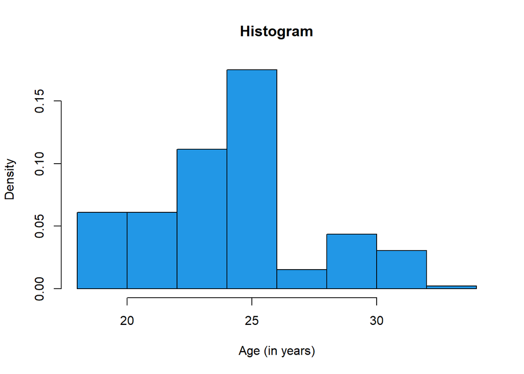

```r
hist(lab2_data_csv$age_yr, # numeric variable to plot
     main = "Histogram", # title of graph
     col = 4, # controls the color of the display
     xlab = "Age (in years)", # x axis label
     freq = F)  # set to "F" to plot the density
```

## Graphical Displays: Dot Charts

A plot of a **numeric variable** with a **small sample size** in which each observation is represented by a dot on or above a horizontal measurement scale.

They can be made using the `stripchart()` function.

- Format for plotting:

```r
stripchart(dataframe$variable, # variable to plot
           method = "stack", # results in stacking the dots
           col = 3, # col controls the color
           at = 0,
           # numeric vector giving the locations
           #where the charts should be drawn
           main="Dot Plot of (Variable Name)",
           # graph title
           pch = 19)
           # pch controls the shape, 19 is a solid dot
```

Example plot from Learning Module 2:

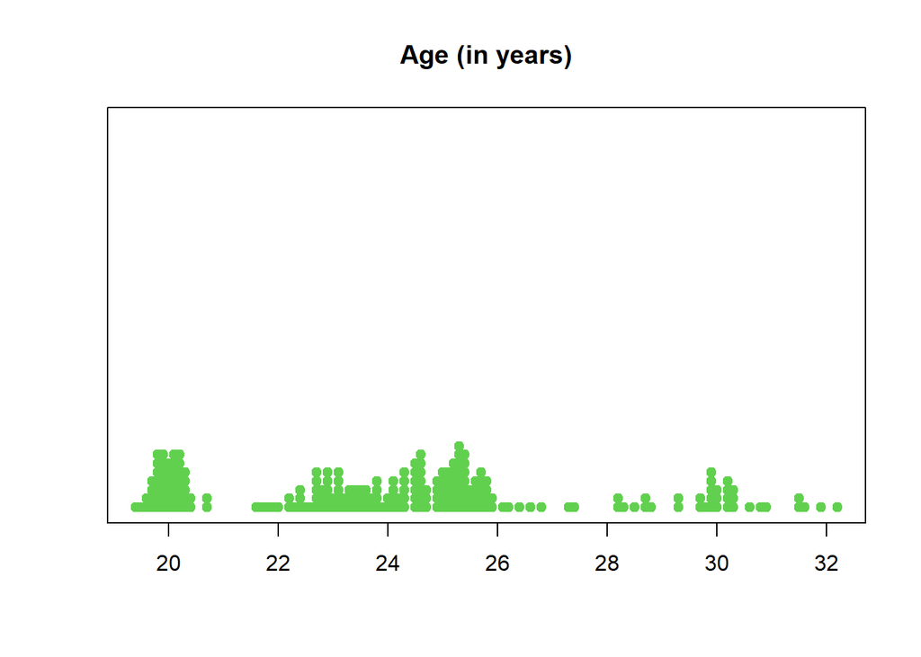

```r
stripchart(lab2_data_csv$age_yr,
           main = "Age (in years)", # set title
           method = "stack", # results in stacking the dots
           col = 3, # col controls the color
           at = 0,
           # numeric vector giving the locations
           # where the charts should be drawn
           pch = 19) # pch controls the shape, 19 is a solid dot
```

## Graphical Displays: Stem-and-Leaf Plots

Stem-and-leaf plots are for **numeric data** when the **sample size is small**.

They can be made using the `stem()` function.

- Format for plotting:

  ```r
  stem(data$variable) # numeric variable to plot
  ```

- Example plot from Learning Module 2:

  ```r
  stem(lab2_data_csv$age_yr) # numeric variable to plot
  ```

  ```
    The decimal point is at the |

    19 | 4566777788888889999999
    20 | 00000011111112222222333334477
    21 | 6789
    22 | 0223444567777788899999
    23 | 0011111223334445556667788889
    24 | 001111223333355555566666667779999
    25 | 0000011111222222333333334444444555666677777888899
    26 | 12468
    27 | 34
    28 | 2235778
    29 | 3377899999
    30 | 0002222333689
    31 | 5569
    32 | 2
  ```

## Saving Graphs

To save a plot generated in R onto your device, follow these steps:

1. Locate the plots tab in the bottom right window
2. Navigate the following: Export –> Save as Image or Save as PDF

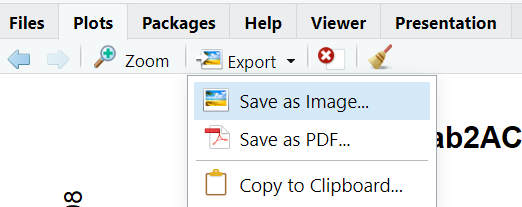

3. Specify the directory, file type (such as PNG), and the name that you want to save for the image file.

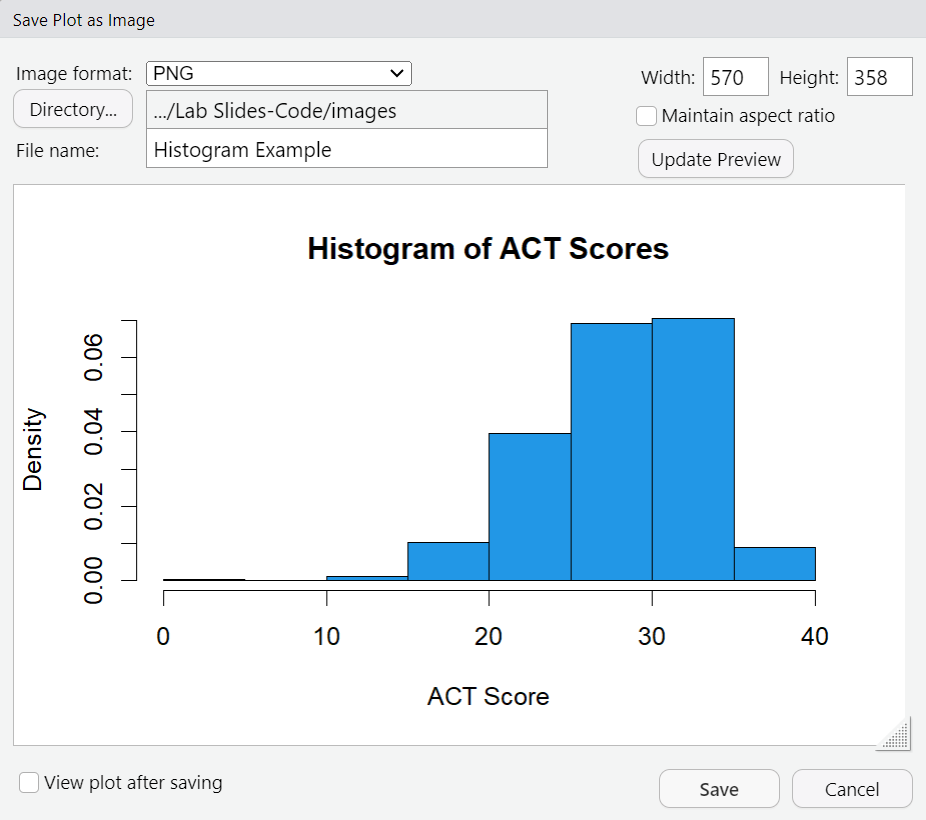

# Compiling a Report in R

**Next week’s lab assignment (Lab 3) will require that you** **submit a compiled report**, not your R script. Practice compiling your R script from this week’s lab assignment.

**How to compile a report in RStudio:**

1. Remove any install.packages() statements from your script or use “#” to comment out that line of code. Reports will not compile if they include an install.packages() statement.
2. In the main menu of RStudio, click ‘File’ and then select ‘Compile Report’ OR click on the icon, as shown below:

[figure not shown]

3. Save your report as **either a HTML, PDF or MS WORD file**
- **Tip: Make sure that all of your code runs correctly before compiling**
  - For example, your report will not compile if you reference an object that has not been created in your R script.

# Lab Activity

Now let’s use a different dataset to practice data importing and visualization ✨

## Practice Dataset

This practice dataset, “lab2ACTScores”, is a subset of the [sat.act dataset](https://personality-project.org/r/psych/help/sat.act.html) in the [`psych` R package](https://personality-project.org/r/psych/help/00Index.html) collected as part of the [Synthetic Aperture Personality Assessment (SAPA) web based personality assessment project](https://www.sapa-project.org/).

We will only use this dataset for teaching purpose in this lab.

- There are a total of 643 observations on the following 4 variables:
  - `ACT`: ACT composite scores may range from 1 - 36. National norms have a mean of 20.
  - `age`: age of participants
  - `gender`: self-reported gender (male/female)
  - `education`: self-reported education levels (HS/finished HS/some college/college graduate/graduate degree)

## Activity 1 (Your Turn)

Now try to import the lab2ACTScores dataset into R.

You can locate it on Canvas under “Lab-2” page.

It is up to you to choose either the .txt or .csv file.

💡 **Hint**: think about the type of data for these variables! Do you have the appropriate data types after importing dataset?

```r
# SOLUTION
## Step 1: set working directory
setwd(dir = "/Users/jane/Documents/GitHub/PSC103A/Lab2")
## Step 2: import dataset
activity_data <- read.csv(file = "lab2ACTScores.csv", # relative path if set up working directory
                          header = T, stringsAsFactors = T)
## Step 3: check dataset
head(activity_data)
## Step 4: check data types
str(activity_data)
```

## Activity 2 (Together)

Create a bar chart of gender using relative frequencies. **Make sure to include a main title and the y-axis and x-axis labels.** Export the graph and save it in your computer.

💡 **Hint**: Don’t forget to create an object for the relative frequencies!

```r
# SOLUTION
## Step 1: find frequencies
gender_freq = table(activity_data$gender)
## Step 2: calculate relative frequencies
gender_relfreq = gender_freq / length(activity_data$gender)
## Step 3: make bar chart
barplot(gender_relfreq, # the stored object for relative frequencies
        main = "Relative Frequency by Gender", # give our graph a name
        ylab = "Relative Frequency", # always label the y-axis
        names.arg = c("Female", "Male"), # label the categories
        col = c(2,4)) # make the bars colorful
```

## Activity 3 (In Groups)

Create a graphical display of age that shows the densities (not frequencies). **Make sure to include a main title and the y-axis and x-axis labels.** Export your work as a compiled report and save it as either a HTML, PDF or MS WORD file.

💡 **Hint**: How many observations are in this dataset? Is that number large or small? Which display is the most appropriate given the number of observations?

```r
# Looking for SOLUTION?

## Think about the hints! Revisit previous slides if need to :)
## Try it out yourself!
```